# DC Youth Stats

# In summary

- Much of the 2010s growth is actually a return to the child population DC had around 2000.
- Some of DC’s 2010s child population growth came from more births. That happened because more adults of childbearing age lived here, not because fertility rose (it fell).
- Child net out-migration also shrank, though it remained negative at every child age.
- Roughly a third of the swing from population decline in the 2000s to growth in the 2010s came from a smaller cohort aging out, a legacy of the 2000s’ low point in youth population.
- The population gains were concentrated among Hispanic, non-Hispanic White, and higher-income families. The number of Black children fell.

# Appendix

**Click here to show/hide the appendix**

The plot shows the number of children that DC residents listed on their federal tax returns. The totals are slightly different from the Census totals, and show a decline starting in 2019, rather than 2020.

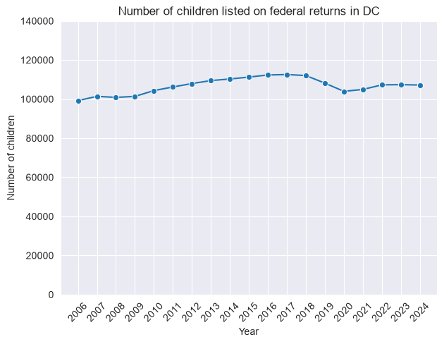

The chart below shows more detail on the distribution of household income in DC over time.

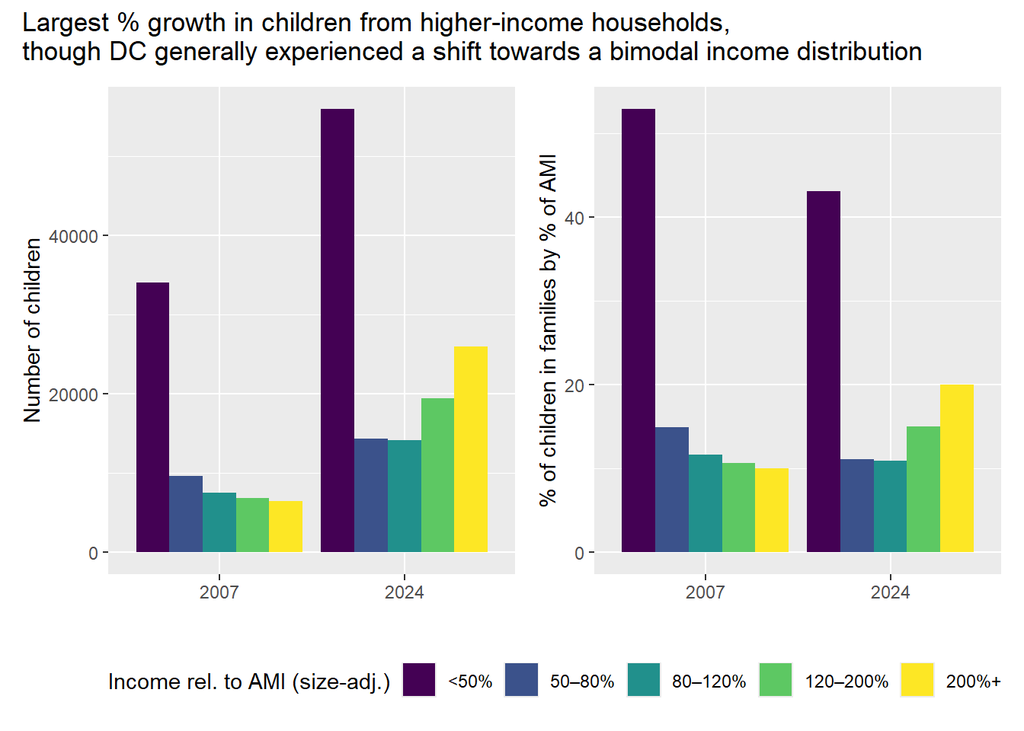

```r
appendix_income_chart
```

The chart below shows general fertility rates for the counties encompassing different U.S. cities between 1982 and 2024. The vast majority of U.S. cities saw large declines in the GFR. DC’s decline was sort of in the middle.

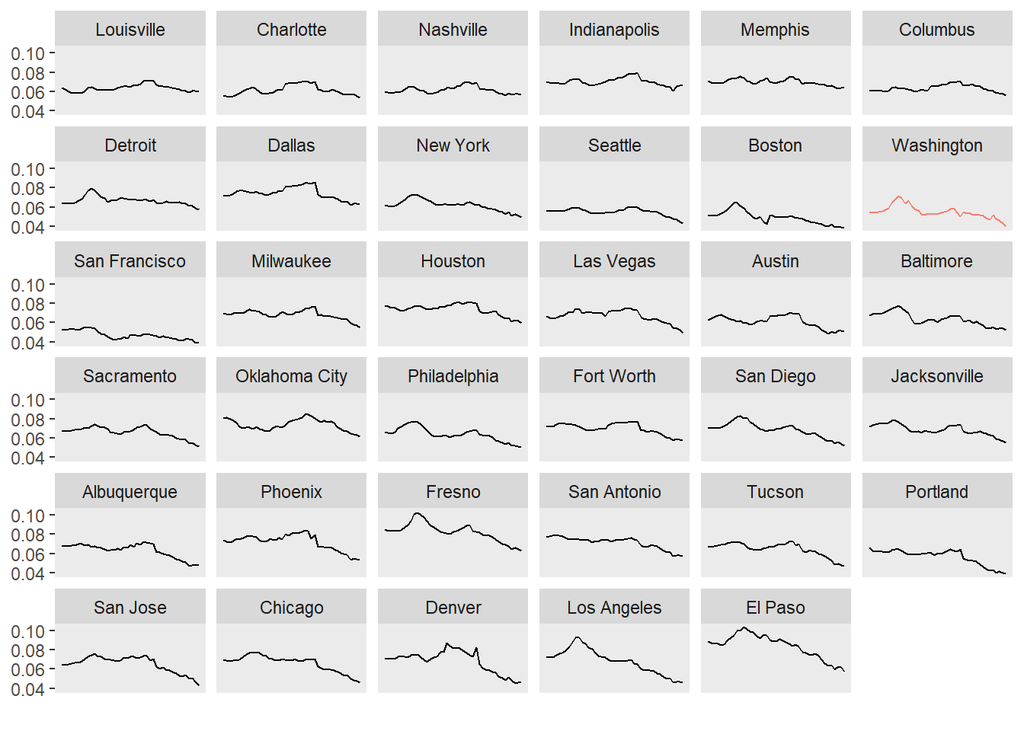

```r
  fert %>%
  group_by(city, year) %>%
  summarise(
      births=sum(births, na.rm=T)
    , age1544_fem=sum(age1544_fem, na.rm=T)
    , gfr = births / age1544_fem
    , .groups='drop'
    ) %>%
  group_by(city) %>%
  mutate(change = gfr[year==1985] - gfr[year==2024]) %>%
  ungroup() %>%
  mutate(DC = if_else(city == "Washington", 1, 0)) %>%
  ggplot(aes(x=year, y=gfr
             , color=factor(DC)
             )
         ) +
  geom_line() +
  labs(x="", y="GFR") +
  guides(color="none") +
  scale_color_manual(values = c("black", "salmon")) +
  theme(
    panel.grid = element_blank(),
    axis.title.y = element_blank(), # Removes the main Y-axis title ("mpg")
    # axis.text.y  = element_blank(), # Removes the tick labels (numbers)
    # axis.ticks.y = element_blank(), # Removes the small tick marks

    axis.ticks.x = element_blank(),  # Removes the small tick marks
    axis.text.x  = element_blank()  # Removes the tick labels (numbers)
  ) +
  facet_wrap(~forcats::fct_reorder(city, change))
```

## Decomposing population changes

The charts below, using data from the Census Bureau and the University of Wisconsin, show that DC had very high youth out-migration during the 1990s and 2000s. This is partly why there was less aging out of the youth cohort in the 2010s–there were just fewer kids at the start of the decade, in 2010, that could have aged out by 2020. The 2000s were the nadir of DC’s youth-age population.

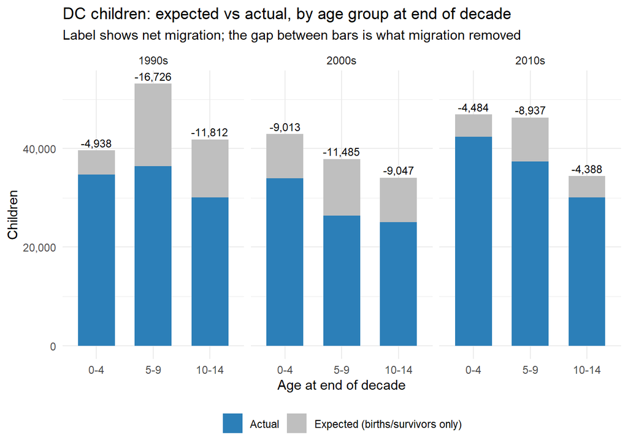

```r
appendix_p1
```

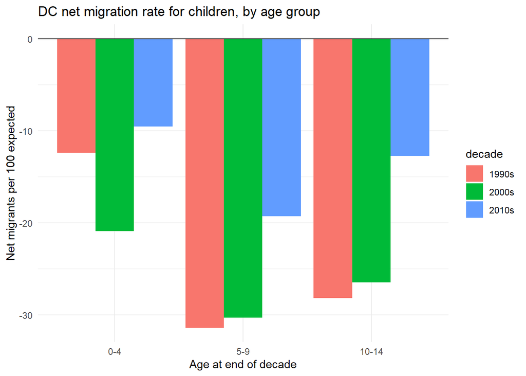

```r
appendix_p2
```

Net migration for children in DC has been negative for decades, but during the 2010s, it was less negative.

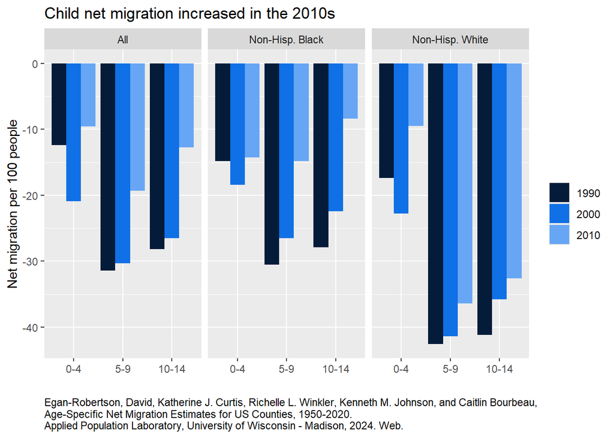

```r
temp_df <- read_csv("~/GitHub/youth-stats/data/net_migration_wisc.csv") %>%
  mutate(group = case_when(
      group=="Total"~"All"
    , group=="NH_Black" ~ "Non-Hisp. Black"
    , group=="NH_White" ~ "Non-Hisp. White"
    )
    ) %>%
  mutate(age = factor(age, levels = c("0-4", "5-9", "10-14", "15-19"))) %>%
  filter(age != "15-19")

ggplot(temp_df, aes(x=age, y=net_migration_per_100_people, fill=factor(decade))) +
  geom_bar(stat = "identity", position="dodge") +
  scale_fill_manual(values = c("#041C39", "#1070E5", "#67A6F4")) +
  facet_grid(~group) +
  labs(
      x="", y="Net migration per 100 people", title="Child net migration increased in the 2010s"
      , fill=""
    , caption="Egan-Robertson, David, Katherine J. Curtis, Richelle L. Winkler, Kenneth M. Johnson, and Caitlin Bourbeau,\nAge-Specific Net Migration Estimates for US Counties, 1950-2020.\nApplied Population Laboratory, University of Wisconsin - Madison, 2024. Web.") +
  theme(
    plot.caption = element_text(hjust = 0)
  )
```

This tracks with population trends across all age groups, which show that DC’s 2010s population boom was largely driven by increasing net migration.

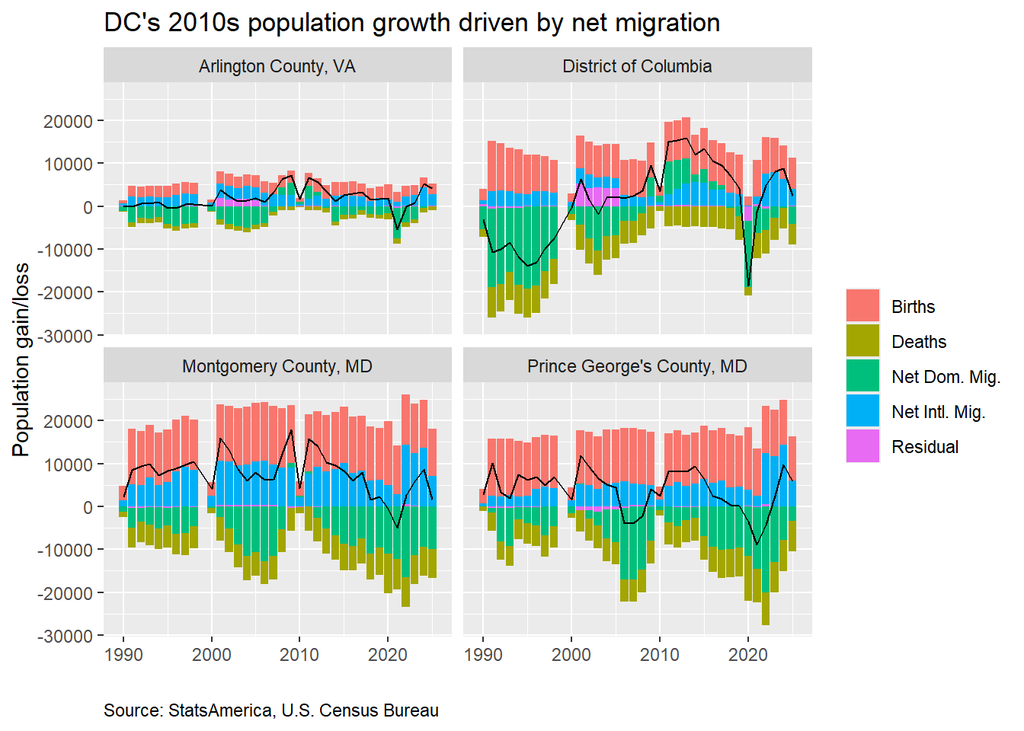

```r
df <- read_csv("~/GitHub/youth-stats/data/components_of_population_change.csv") %>%
  select(-`...11`) %>%
  select(Description, Year, Births, Deaths
         , `Net International Migration`, `Net Domestic Migration`, `Residual`) %>%
  mutate(Deaths = Deaths * -1) %>%
  pivot_longer(cols = -c("Description", "Year"), names_to = "var") %>%
  filter(Description %in% c(
      "District of Columbia"
    , "Arlington County, VA"
    , "Montgomery County, MD"
    , "Prince George's County, MD"
    )
    ) %>%
  filter(Year!=1999) %>%
  group_by(Year, Description) %>%
  mutate(Total = sum(value)) %>%
  ungroup() %>%
  mutate(var = case_when(
      var=="Net Domestic Migration" ~ "Net Dom. Mig."
    , var=="Net International Migration" ~ "Net Intl. Mig."
    , .default=var
  ))

ggplot(data=df) +
  geom_bar(
             aes(x=Year, y=value, fill=factor(var))
           , stat="identity"
           ) +
  geom_line(aes(x=Year, y=Total)) +
  facet_wrap(~Description) +
  labs(x="", y="Population gain/loss", fill=""
       , caption="Source: StatsAmerica, U.S. Census Bureau"
       , title="DC's 2010s population growth driven by net migration"
       ) +
  theme(
    plot.caption = element_text(hjust=0)
  )
```

```r
years  <- c(2005:2024)          # match the IPUMS out-migration series
groups <- list("1-4" = 1:4, "5-15" = 5:15)

# ---- IPUMS out-migration (weighted counts, MIGPLAC1 == DC) -------------
# https://sda.usa.ipums.org/sdaweb/analysis/?dataset=all_acs_samples
# migplac1(11), migrate1(3), age(10-15)
out_migration_from_dc <- data.frame(
  year  = rep(2005:2024, 2),
  group = rep(c("1-4", "5-15"), each = 20),
  out_mig     = c(
    2525, 1741, 3518, 1732, 3169, 3947, 2068, 2757, 3854, 2049,
    3140, 3297, 3159, 2018, 2315, 876, 3610, 1778, 2025, 3082,

    5540, 5085, 3709, 4978, 3476, 5170, 2486, 3439, 3213, 2707,
    5360, 3835, 5961, 5301, 3500, 1779, 4159, 5345, 4627, 3466
  )
)

# migrate1(3), age(5-15), statefip(11)
in_migration_to_dc <- data.frame(
  year  = rep(2005:2024, 2),
  group = rep(c("1-4", "5-15"), each = 20),
  in_mig     = c(
    1395, 2362, 1859, 1104, 1372, 752, 1012, 1098, 980, 654,
    762, 1123, 1293, 1301, 896, 1822, 542, 970, 979, 1075,

    2161, 1361, 2666, 1073, 2176, 1205, 2255, 2483, 913,
    1316, 1351, 1571, 2218, 1346, 1351, 1259, 1843, 2181, 2483, 1106
  )
)

df <- dplyr::inner_join(in_migration_to_dc, out_migration_from_dc, by=c("year", "group")) %>%
  mutate(net = in_mig - out_mig)

ggplot(df, aes(x=year, y=net)) +
  geom_point(alpha=.5) + geom_smooth(weight = .6, alpha=.2) +
  geom_hline(aes(yintercept=0)) +
  theme_minimal() +
  facet_wrap(~group) +
  labs(title="Net migration by age group in DC in the 1-year ACS")
```

[output not shown]

## School enrollment data

```r
clean_data <- function(df) {
  df %>%
  pivot_longer(
    cols = -c(  `School Name`
              , `State Name [Public School] Latest available year`
              , `School ID (12-digit) - NCES Assigned [Public School] Latest available year`
              ),
    names_to = c(".value", "school_year"),
    names_pattern = "(.*)(.{7})$"
  ) %>%
    rename(
        "id" = "School ID (12-digit) - NCES Assigned [Public School] Latest available year"
      , "name" = "School Name"
      , "state" = "State Name [Public School] Latest available year"
      ) %>%
    rename_with(~ str_remove(., fixed("[Public School]")), everything()) %>%
    rename_with(str_trim) %>%
    filter(!is.na(state)) %>%
    select(-state)
}


# Data from here:
  # https://nces.ed.gov/ccd/elsi/tableGenerator.aspx


df1 <- read_csv("~/GitHub/youth-stats/data/ELSI_csv_export_6392212884336770323709.csv", skip = 5) %>%
  clean_data(.) %>%
  rename(lat=Latitude, lon=Longitude)

df2 <- read_csv("~/GitHub/youth-stats/data/ELSI_csv_export_6392212902055494018674.csv", skip = 5) %>%
  clean_data(.)

df3 <- read_csv("data/ELSI_csv_export_6392212906851656167285.csv", skip = 5) %>%
  clean_data(.) %>%
  select(-`Grades 1-8 Students`, -`Grades 9-12 Students`)

df4 <- read_csv("data/ELSI_csv_export_639221340086678151282.csv", skip=5) %>%
  clean_data(.)

df5 <- read_csv("data/ELSI_csv_export_6392213789371741314818.csv", skip=5) %>%
  clean_data(.)

df6 <- read_csv("data/ELSI_csv_export_6392560370254964395927.csv", skip=5) %>%
  clean_data(.)

df <-
  dplyr::full_join(df1, df2, by = c("id", "name", "school_year")) %>%
  dplyr::full_join(df3, by = c("id", "name", "school_year")) %>%
  dplyr::full_join(df4, by = c("id", "name", "school_year")) %>%
  dplyr::full_join(df5, by = c("id", "name", "school_year")) %>%
  dplyr::full_join(df6, by = c("id", "name", "school_year")) %>%
  mutate(id = as.character(id)) %>%
  mutate(across(everything(), ~ na_if(., "†"))) %>%
  mutate(across(everything(), ~ na_if(., "–"))) %>%
  mutate(across(everything(), ~ na_if(., "‡"))) %>%
  rename(addr = `Location Address 1`) %>%
  group_by(id, name) %>%
  mutate(
      lat = first(lat, na_rm = TRUE)
    , lon = first(lon, na_rm = TRUE)
    , addr = first(addr, na_rm = TRUE)
    ) %>%
  ungroup() %>%
  mutate(school_year = as.numeric(str_sub(school_year, start = 1, end = 4))) %>%
  mutate(across(-c(id, name, addr), as.numeric))


rm(df1, df2, df3, df4, df5)

tot_enroll <-
  df %>%
  group_by(school_year) %>%
  summarise(
      Total                 = sum(`Total Students All Grades (Excludes AE)`, na.rm=T)
    , `Free Lunch Eligible` = sum(`Free Lunch Eligible`, na.rm=T)
    , `Lower`               = sum(`Grades 1-8 Students`, na.rm=T)
    , `Upper`               = sum(`Grades 9-12 Students`, na.rm=T)
    , `Black`               = sum(`Black or African American Students`, na.rm=T)
    , `White`               = sum(`White Students`, na.rm=T)
    , `Hispanic`            = sum(`Hispanic Students`, na.rm=T)
    , `AAPI`                = sum(`Asian or Asian/Pacific Islander Students`, na.rm=T)
    , `Two or more`         = sum(`Two or More Races Students`, na.rm=T)
    , `AIAN`                = sum(`American Indian/Alaska Native Students`, na.rm=T)
    , NHPI                  = sum(`Nat. Hawaiian or Other Pacific Isl. Students`, na.rm=T)
    , Other                 = AAPI + AIAN + NHPI + `Two or more`
    , tot_race              = sum(`Total Race/Ethnicity`, na.rm=T)
    , my_sum                = Black + Hispanic + Other + White
    , diff                  = round((my_sum - tot_race)/ tot_race*100, 2)
    , check_sum             = my_sum == tot_race
    , .groups               = 'drop'
  ) %>%
  mutate(across(where(is.numeric), ~na_if(., 0)))
```

DC’s school enrollment data mirrors these Census trends.

Total enrollment in DC Public Schools (including charter schools, which first opened in 1996) has risen from roughly 80,694 to 92,657 since 1990.[^13] All of this increase came after 2010. Black student enrollment fell, while Hispanic and Non-Hispanic White student enrollment increased significantly.[^14]

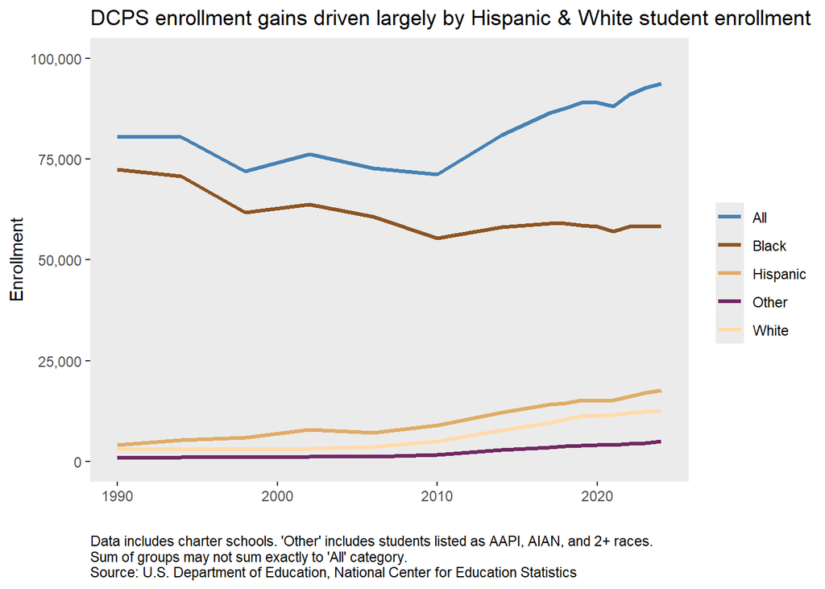

```r
plt1 <-
  ggplot(tot_enroll %>% filter(school_year>=1990), aes(x=school_year)) +
  geom_line(aes(y=Total,    color="All"),      linewidth=ms) +
  geom_line(aes(y=Black,    color="Black"),    linewidth=ms) +
  geom_line(aes(y=Hispanic, color="Hispanic"), linewidth=ms) +
  geom_line(aes(y=Other,    color="Other"),    linewidth=ms) +
  geom_line(aes(y=White,    color="White"),    linewidth=ms) +
  # theme_minimal() +
  scale_y_continuous(
      labels = scales::label_comma()
    , limits = c(0, 100e3)
    ) +
  scale_color_manual(values = c(
              "All"=total_col
            , "Black"=black_col
            , "Hispanic"=hispa_col
            , "Other"=other_col
            , "White"=white_col
            )) +
  labs(x="", y="Enrollment", color = "",
       caption="Data includes charter schools. 'Other' includes students listed as AAPI, AIAN, and 2+ races.\nSum of groups may not sum exactly to 'All' category.\nSource: U.S. Department of Education, National Center for Education Statistics",
       title = "DCPS enrollment gains driven largely by Hispanic & White student enrollment"
         ) +
  theme(
     plot.caption = element_text(hjust = 0)
    , panel.grid = element_blank()
    )


plt1
```

Since 1990, schools in wards 1, 7, and 8 have lost students, at least according to the DoE data that lists school locations. Wards 2, 3, 4, and 5 have seen significant increases. The trend in Ward 6 has been mostly flat.[^15]

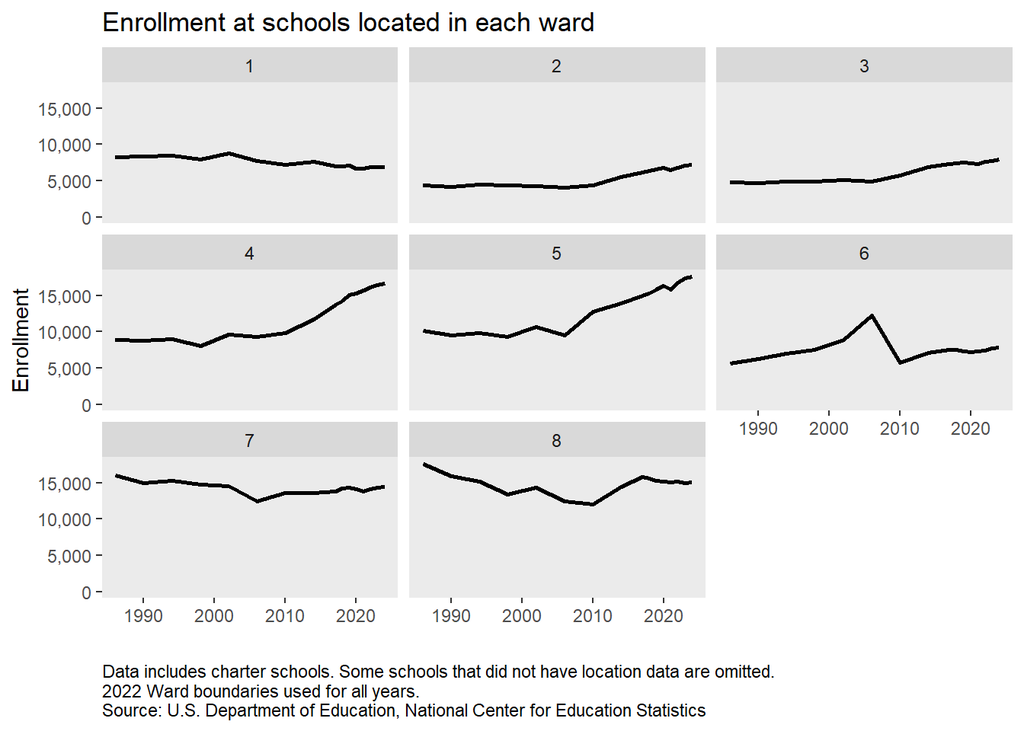

```r
# Map schools
wards <- sf::st_read("data/Ward_-_2022.geojson", quiet=T)

points_sf <- df %>%
  select(name, id, lat, lon) %>% distinct() %>%
  filter(!is.na(lat)) %>%
  st_as_sf(coords = c("lon", "lat"), crs = 4326)

joined_sf <- st_join(points_sf, wards, join = st_intersects) %>%
  select(name, id, WARD) %>% distinct() %>% st_drop_geometry()

df <- df %>%
  dplyr::left_join(joined_sf, by=c("id", "name"))


ward_enroll <- df %>%
  group_by(WARD, school_year) %>%
  summarise(
      Total                 = sum(`Total Students All Grades (Excludes AE)`, na.rm=T)
    , `Free Lunch Eligible` = sum(`Free Lunch Eligible`, na.rm=T)
    , `Lower`               = sum(`Grades 1-8 Students`, na.rm=T)
    , `Upper`               = sum(`Grades 9-12 Students`, na.rm=T)
    , `Black`               = sum(`Black or African American Students`, na.rm=T)
    , `White`               = sum(`White Students`, na.rm=T)
    , `Hispanic`            = sum(`Hispanic Students`, na.rm=T)
    , `AAPI`                = sum(`Asian or Asian/Pacific Islander Students`, na.rm=T)
    , `Two or more`         = sum(`Two or More Races Students`, na.rm=T)
    , `AIAN`                = sum(`American Indian/Alaska Native Students`, na.rm=T)
    , NHPI                  = sum(`Nat. Hawaiian or Other Pacific Isl. Students`, na.rm=T)
    , Other                 = AAPI + AIAN + NHPI + `Two or more`
    , tot_race              = sum(`Total Race/Ethnicity`, na.rm=T)
    , my_sum                = Black + Hispanic + Other + White
    , diff                  = round((my_sum - tot_race)/ tot_race*100, 2)
    , check_sum             = my_sum == tot_race
    , .groups               = 'drop'
  ) %>%
  mutate(across(where(is.numeric), ~na_if(., 0))) %>%
  filter(!(is.na(WARD)))


plt2 <-
  ggplot(ward_enroll, aes(x=school_year, y=Total)) +
  geom_line(linewidth=ms-.2) +
  scale_y_continuous(
      labels = scales::label_comma()
    , limits = c(0, max(ward_enroll$Total, na.rm=T)+10)
    ) +
  facet_wrap(~WARD) +
  labs(x="", y="Enrollment",
       caption="Data includes charter schools. Some schools that did not have location data are omitted.\n2022 Ward boundaries used for all years.\nSource: U.S. Department of Education, National Center for Education Statistics",
       title = "Enrollment at schools located in each ward"
         ) +
  scale_color_brewer(palette = "Set1") +
  theme(
     plot.caption = element_text(hjust = 0)
    , panel.grid = element_blank()
    )

plt2
```

Enrollment at schools located in Wards 1, 7, and 8 has fallen since 1990.

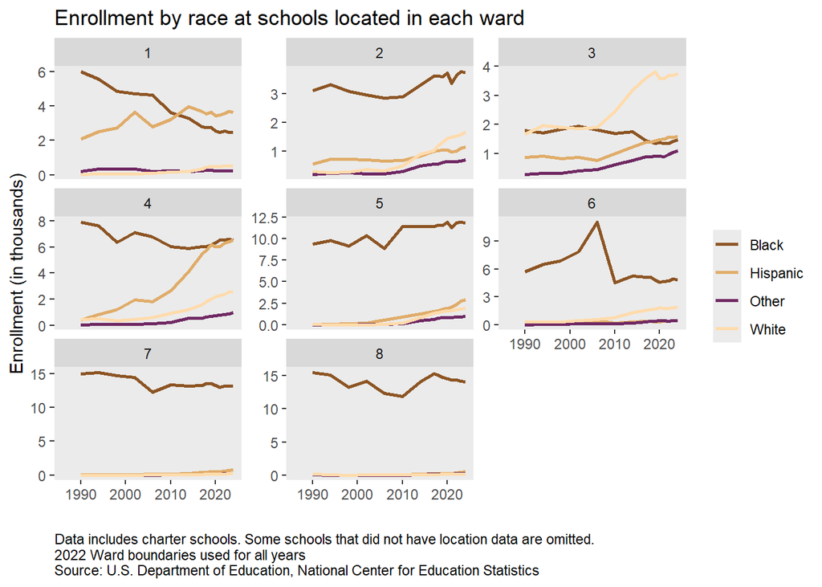

```r
ward_enroll_long <- ward_enroll %>%
  select(WARD, school_year, Black, Hispanic, Other, White) %>%
  pivot_longer(cols = -c(WARD, school_year), names_to = "Group", values_to = "Enrollment")

plt3 <-
  ggplot(ward_enroll_long, aes(x=school_year, y=Enrollment/1000, color=Group)) +
  geom_line(linewidth=ms-.2) +
  scale_y_continuous(
      labels = scales::label_comma()
    ) +
  scale_color_manual(values = c(
              "Black"=black_col
            , "Hispanic"=hispa_col
            , "Other"=other_col
            , "White"=white_col
            )) +
  facet_wrap(~WARD, scales="free_y") +
  labs(x="", y="Enrollment (in thousands)", color = "",
       caption="Data includes charter schools. Some schools that did not have location data are omitted.\n2022 Ward boundaries used for all years\nSource: U.S. Department of Education, National Center for Education Statistics",
       title = "Enrollment by race at schools located in each ward"
         ) +
  theme(
     plot.caption = element_text(hjust = 0)
    , panel.grid = element_blank()
    )

plt3
```

[^1]: District of Columbia Population Statistics (2025). KIDS COUNT Data Center. Aecfkidscount; Annie E. Casey Foundation. https://datacenter.aecf.org/data/tables/102-child-population-by-gender
[^2]: Methodological note: This page uses populations figures from several different sources, including the American Community Survey, the Decennial Census, and tax returns. Each of these sources shows slightly different population totals. The Decennial Census under-counted children in 2020, for example, but the Census’ population estimates try to adjust for this by referencing administrative data. The KidsCount figures shown in this first chart are based on Census population estimates, which run about 10,000 above the 2020 Census count used elsewhere on this page.
[^3]: Azimeraw, M., & Phillips, J. (2010). District Population Trends 1800 to 2009. District of Columbia State Data Center Monthly Brief. https://planning.dc.gov/sites/default/files/dc/sites/op/publication/attachments/DCOP_SDC_June%25202010%2520Briefing%2520Report.pdf I supplement this time series with 2025 data from KidsCount: https://datacenter.aecf.org/data/tables/99-total-population-by-child-and-adult-populations?loc=10
[^4]: See methodological note above.
[^5]: National Center for Family & Marriage Research (2026). County-, state-, and national-level birth counts and fertility rates, United States, 1982–2024. Marriage, Divorce, & Birth Data Compass. Bowling Green State University. Retrieved from https://www.bgsu.edu/ncfmr/resources/data/original-data/county-level-birth-data-1982-2024
[^6]: See also https://edscape.dc.gov/page/pop-and-students-number-births-and-birth-rates
[^7]: Mayor Vincent C. Gray and DC Department of Health announce historic decrease in district’s infant mortality rate. (2016). DC.Gov. https://dchealth.dc.gov/es/release/mayor-vincent-c-gray-and-dc-department-health-announce-historic-decrease-district%E2%80%99s-infant-0
[^8]: DC health highlights progress in maternal and infant health in perinatal health report | doh. (2016). DC.Gov. https://dchealth.dc.gov/release/dc-health-highlights-progress-maternal-and-infant-health-perinatal-health-report
[^9]: https://www.ncbi.nlm.nih.gov/books/NBK215693/
[^10]: https://en.wikipedia.org/wiki/Low_base_effect
[^11]: Note: figures are decennial census counts for all three years. Census population estimates, which adjust for the 2020 undercount of young children, would show a larger 2020 total.
[^12]: See Yesim Sayin, Kids in the Neighborhood: The District Has More Children, But They Are Not Where They Used to Be. https://ora-cfo.dc.gov/blog/kids-neighborhood-district-has-more-children-they-are-not-where-they-used-be
[^13]: U.S. Department of Education, National Center for Education Statistics’ [Common Core of Data](https://nces.ed.gov/ccd/elsi/tableGenerator.aspx)
[^14]: Starting around 2010, the Department of Education started listing “2 or more races as an option”; this altered totals for the other groups.
[^15]: Because students can attend schools citywide, and many schools opened or closed over this period, this reflects school locations more than where children live per se.